# FLIGHT PRICE PREDICTION

```python
from google.colab import drive
drive.mount('/content/drive')
```

prepared by: 20114261 Abdul Ahad Khan, 20114264 Ayushi Mishra, 20114271 Shubhendu Singh, 20114016 Razi Haneef, 20114021 Sk Raju

# Importing the modules

```python
import pandas as pd
import numpy as np
import matplotlib.pyplot as plt
%matplotlib inline
import seaborn as sns
import datetime

from sklearn.preprocessing import OneHotEncoder
from sklearn.compose import ColumnTransformer

import re

from sklearn.model_selection import train_test_split
from sklearn.preprocessing import StandardScaler

from sklearn.metrics import mean_squared_error as mse
from sklearn.metrics import r2_score

from math import sqrt

from sklearn.model_selection import GridSearchCV
from sklearn.model_selection import RandomizedSearchCV

from sklearn.neighbors import KNeighborsRegressor
from sklearn.linear_model import Ridge
from sklearn.tree import DecisionTreeRegressor
from sklearn.ensemble import RandomForestRegressor
from mlxtend.regressor import StackingRegressor
```

# Fitting all the columns in page width

```python
pd.pandas.set_option('display.max_columns', None)
```

# Importing the datasets

Two raw datasets are integrated here as the attributes are same in both cases.. One for pek to sha and another for sha to pek.

```python
dataset_1 = pd.read_csv('/content/drive/MyDrive/Data for Air Price prediction/pek-sha.csv')
dataset_2 = pd.read_csv('/content/drive/MyDrive/Data for Air Price prediction/sha-pek.csv')
dataset = pd.concat([dataset_1,dataset_2], ignore_index = True)
```

# Shape of the dataset

Showing the number of rows and columns

```python
print(dataset.shape)
```

```
(568917, 14)
```

Showing the head part and tail part of the data

```python
dataset.head()
```

|  | ID | flightNumber | craftTypeCode | depAirport | traAirport | arrAirport | departureDate | arrivalDate | cabinClass | priceClass | price | rate | createDate | dateDifference |
| --- | --- | --- | --- | --- | --- | --- | --- | --- | --- | --- | --- | --- | --- | --- |
| 0 | 14393 | HO1252 | 320 | PEK | NaN | SHA | 2019-01-04 06:35:00 | 2019-01-04 08:55:00 | C | C | 1860 | 1.00 | 2019-01-03 14:26:15 | 1 |
| 1 | 14409 | MU5138 | 33L | PEK | NaN | SHA | 2019-01-04 07:00:00 | 2019-01-04 09:15:00 | C | I | 1640 | 0.31 | 2019-01-03 14:26:15 | 1 |
| 2 | 14415 | MU5138 | 33L | PEK | NaN | SHA | 2019-01-04 07:00:00 | 2019-01-04 09:15:00 | C | J | 5360 | 1.00 | 2019-01-03 14:26:15 | 1 |
| 3 | 14429 | HU7605 | 350 | PEK | NaN | SHA | 2019-01-04 07:20:00 | 2019-01-04 09:35:00 | C | I | 1635 | 0.29 | 2019-01-03 14:26:15 | 1 |
| 4 | 14431 | HU7605 | 350 | PEK | NaN | SHA | 2019-01-04 07:20:00 | 2019-01-04 09:35:00 | C | I | 1640 | 0.29 | 2019-01-03 14:26:15 | 1 |

```python
dataset.tail()
```

|  | ID | flightNumber | craftTypeCode | depAirport | traAirport | arrAirport | departureDate | arrivalDate | cabinClass | priceClass | price | rate | createDate | dateDifference |
| --- | --- | --- | --- | --- | --- | --- | --- | --- | --- | --- | --- | --- | --- | --- |
| 568912 | 77617774 | MU5389 | 325 | SHA | LYA | PEK | 2019-07-21 07:20:00 | 2019-07-21 12:00:00 | Y | R | 830 | 0.56 | 2019-07-14 23:28:01 | 7 |
| 568913 | 77617775 | MU5389 | 325 | SHA | LYA | PEK | 2019-07-21 07:20:00 | 2019-07-21 12:00:00 | Y | R | 880 | 0.60 | 2019-07-14 23:28:01 | 7 |
| 568914 | 77617776 | MU5389 | 325 | SHA | LYA | PEK | 2019-07-21 07:20:00 | 2019-07-21 12:00:00 | Y | R | 920 | 0.62 | 2019-07-14 23:28:01 | 7 |
| 568915 | 77617777 | MU5389 | 325 | SHA | LYA | PEK | 2019-07-21 07:20:00 | 2019-07-21 12:00:00 | Y | R | 790 | 0.54 | 2019-07-14 23:28:01 | 7 |
| 568916 | 77617779 | MU5389 | 325 | SHA | LYA | PEK | 2019-07-21 07:20:00 | 2019-07-21 12:00:00 | Y | Y | 1490 | 1.00 | 2019-07-14 23:28:01 | 7 |

# Finding the length of unique values for each attribute

```python
dataset.nunique()
```

```
ID                568917
flightNumber         100
craftTypeCode         45
depAirport             2
traAirport             1
arrAirport             2
departureDate      12823
arrivalDate        14704
cabinClass             3
priceClass            32
price                681
rate                  87
createDate          1249
dateDifference        15
dtype: int64
```

Showing unique values in some attributes

```python
dataset.depAirport.unique()
```

```
array(['PEK', 'SHA'], dtype=object)
```

```python
dataset.arrAirport.unique()
```

```
array(['SHA', 'PEK'], dtype=object)
```

```python
dataset.traAirport.unique()
```

```
array([nan, 'LYA'], dtype=object)
```

```python
dataset.cabinClass.unique()
```

```
array(['C', 'F', 'Y'], dtype=object)
```

```python
dataset.priceClass.unique()
```

```
array(['C', 'I', 'J', 'R', 'D', 'Z', 'Q', 'A', 'F', 'P', 'U', 'T', 'Y',
       'S', 'W', 'L', 'S1', 'V', 'B', 'M', 'G', 'H', 'K', 'E', 'N', 'X',
       'M1', 'BZ', 'XC', 'MC', 'NZ', 'VZ'], dtype=object)
```

# Checking the missing values

```python
#This will check the missing values percentage in columns
features_with_na=[features for features in dataset.columns if dataset[features].isnull().sum()>1]
for feature in features_with_na:
    print(feature, np.round(dataset[feature].isnull().mean()*100, 4),  ' % missing values')
```

```
traAirport 98.0909  % missing values
```

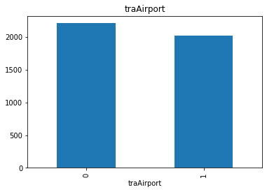

```python
#This will check the importance of missing values
for feature in features_with_na:
    data = dataset.copy()

    data[feature] = np.where(data[feature].isnull(),0,1)
    data.groupby(feature)['price'].mean().plot.bar()
    plt.title(feature)
    plt.show()
```

# Checking for Duplicate rows

```python
duplicate = dataset[dataset.duplicated(keep = False)]
duplicate
```

|  | ID | flightNumber | craftTypeCode | depAirport | traAirport | arrAirport | departureDate | arrivalDate | cabinClass | priceClass | price | rate | createDate | dateDifference |
| --- | --- | --- | --- | --- | --- | --- | --- | --- | --- | --- | --- | --- | --- | --- |

# Data description

```python
numerical_features = [feature for feature in dataset.columns if dataset[feature].dtypes != 'O']
print('Number of numerical variables: ', len(numerical_features))
dataset[numerical_features].head()
```

```
Number of numerical variables:  4
```

|  | ID | price | rate | dateDifference |
| --- | --- | --- | --- | --- |
| 0 | 14393 | 1860 | 1.00 | 1 |
| 1 | 14409 | 1640 | 0.31 | 1 |
| 2 | 14415 | 5360 | 1.00 | 1 |
| 3 | 14429 | 1635 | 0.29 | 1 |
| 4 | 14431 | 1640 | 0.29 | 1 |

```python
dataset.describe()
```

|  | ID | price | rate | dateDifference |
| --- | --- | --- | --- | --- |
| count | 5.689170e+05 | 568917.000000 | 568917.000000 | 568917.000000 |
| mean | 3.709192e+07 | 2203.161693 | 0.768114 | 6.586815 |
| std | 2.292971e+07 | 1747.347610 | 0.250103 | 7.407127 |
| min | 3.149000e+03 | 235.000000 | 0.000000 | -1.000000 |
| 25% | 1.747548e+07 | 1010.000000 | 0.530000 | 2.000000 |
| 50% | 3.573651e+07 | 1490.000000 | 0.860000 | 5.000000 |
| 75% | 5.574632e+07 | 2980.000000 | 1.000000 | 7.000000 |
| max | 8.016500e+07 | 6410.000000 | 1.000000 | 30.000000 |

# Adding some columns of interest

Here we converted the datetime attribute to its individual components, taken care of the missing values for the transit airport and added a new attribute named flightDuration.

```python
# Adding a columne named journey,for depAirport 'PEK' we are treating as onward journey and putting 0 in the column value,
#for depAirport 'SHA' we are treating as return journey and putting 1 in the column value.
dataset['journey'] = np.where(dataset['depAirport']=='PEK',0,1)
```

```python
#Adding a column named indirectFlight, if it is a direct flight then putting 0 in the column value else 1.
dataset['indirectFlight'] = np.where(dataset['traAirport']=='LYA',1,0)
```

```python
#extracting departure year,month,date,day,hour from departureDate
dataset['depYear'] = pd.DatetimeIndex(dataset['departureDate']).year
dataset['depMonth'] = pd.DatetimeIndex(dataset['departureDate']).month
dataset['depDate'] = pd.DatetimeIndex(dataset['departureDate']).day
dataset['depDay'] = pd.DatetimeIndex(dataset['departureDate']).dayofweek
dataset['depHour'] = pd.DatetimeIndex(dataset['departureDate']).hour
```

```python
#extracting create year,month,date,day,hour from createDate
dataset['creYear'] = pd.DatetimeIndex(dataset['createDate']).year
dataset['creMonth'] = pd.DatetimeIndex(dataset['createDate']).month
dataset['creDate'] = pd.DatetimeIndex(dataset['createDate']).day
dataset['creDay'] = pd.DatetimeIndex(dataset['createDate']).dayofweek
dataset['creHour'] = pd.DatetimeIndex(dataset['createDate']).hour
```

```python
#converting object type into datetime type
dataset['departureDate'] = pd.to_datetime(dataset['departureDate'])
dataset['arrivalDate'] = pd.to_datetime(dataset['arrivalDate'])
dataset['createDate'] = pd.to_datetime(dataset['createDate'])
```

```python
#Adding a column named flightDuration which is the difference between departure and arrival
dataset['flightDuration']= (dataset['arrivalDate']-dataset['departureDate']).astype('timedelta64[m]')
```

# Dropping rows with invalid value

It's being observed that for some rows departure date is as before creature date. It's being noticed while calculating flightDuration.

```python
#removing rows if it has booking after departure
dataset =  dataset[((dataset['departureDate']-dataset['createDate'])/np.timedelta64(1,'s'))>0]
dataset.shape
```

```
(568742, 27)
```

Showing that mean of price for the whole dataset is not changed after removing the invalid rows as it was smaller in number compare to the dataset.

```python
dataset.price.mean()
```

```
2203.121142802888
```

```python
dataset.shape
```

```
(568742, 27)
```

```python
dataset.head()
```

|  | ID | flightNumber | craftTypeCode | depAirport | traAirport | arrAirport | departureDate | arrivalDate | cabinClass | priceClass | price | rate | createDate | dateDifference | journey | indirectFlight | depYear | depMonth | depDate | depDay | depHour | creYear | creMonth | creDate | creDay | creHour | flightDuration |
| --- | --- | --- | --- | --- | --- | --- | --- | --- | --- | --- | --- | --- | --- | --- | --- | --- | --- | --- | --- | --- | --- | --- | --- | --- | --- | --- | --- |
| 0 | 14393 | HO1252 | 320 | PEK | NaN | SHA | 2019-01-04 06:35:00 | 2019-01-04 08:55:00 | C | C | 1860 | 1.00 | 2019-01-03 14:26:15 | 1 | 0 | 0 | 2019 | 1 | 4 | 4 | 6 | 2019 | 1 | 3 | 3 | 14 | 140.0 |
| 1 | 14409 | MU5138 | 33L | PEK | NaN | SHA | 2019-01-04 07:00:00 | 2019-01-04 09:15:00 | C | I | 1640 | 0.31 | 2019-01-03 14:26:15 | 1 | 0 | 0 | 2019 | 1 | 4 | 4 | 7 | 2019 | 1 | 3 | 3 | 14 | 135.0 |
| 2 | 14415 | MU5138 | 33L | PEK | NaN | SHA | 2019-01-04 07:00:00 | 2019-01-04 09:15:00 | C | J | 5360 | 1.00 | 2019-01-03 14:26:15 | 1 | 0 | 0 | 2019 | 1 | 4 | 4 | 7 | 2019 | 1 | 3 | 3 | 14 | 135.0 |
| 3 | 14429 | HU7605 | 350 | PEK | NaN | SHA | 2019-01-04 07:20:00 | 2019-01-04 09:35:00 | C | I | 1635 | 0.29 | 2019-01-03 14:26:15 | 1 | 0 | 0 | 2019 | 1 | 4 | 4 | 7 | 2019 | 1 | 3 | 3 | 14 | 135.0 |
| 4 | 14431 | HU7605 | 350 | PEK | NaN | SHA | 2019-01-04 07:20:00 | 2019-01-04 09:35:00 | C | I | 1640 | 0.29 | 2019-01-03 14:26:15 | 1 | 0 | 0 | 2019 | 1 | 4 | 4 | 7 | 2019 | 1 | 3 | 3 | 14 | 135.0 |

# Dropping some unnecessary columns

'ID','creYear','depYear' is unique so we can drop it and some othrers columns were also dropped from which we have already extracted the individual components.

```python
dataset = dataset.drop(['ID'], axis=1)
```

```python
dataset = dataset.drop(['depAirport','traAirport','arrAirport','departureDate','arrivalDate','createDate','depYear','creYear'],axis = 1)
```

# Adding an attribute named airline

Generating this attribute by taking the first two letter from flightNumber

```python
dataset['airline'] = dataset['flightNumber'].astype(str).str[0:2]
```

```python
dataset.head()
```

|  | flightNumber | craftTypeCode | cabinClass | priceClass | price | rate | dateDifference | journey | indirectFlight | depMonth | depDate | depDay | depHour | creMonth | creDate | creDay | creHour | flightDuration | airline |
| --- | --- | --- | --- | --- | --- | --- | --- | --- | --- | --- | --- | --- | --- | --- | --- | --- | --- | --- | --- |
| 0 | HO1252 | 320 | C | C | 1860 | 1.00 | 1 | 0 | 0 | 1 | 4 | 4 | 6 | 1 | 3 | 3 | 14 | 140.0 | HO |
| 1 | MU5138 | 33L | C | I | 1640 | 0.31 | 1 | 0 | 0 | 1 | 4 | 4 | 7 | 1 | 3 | 3 | 14 | 135.0 | MU |
| 2 | MU5138 | 33L | C | J | 5360 | 1.00 | 1 | 0 | 0 | 1 | 4 | 4 | 7 | 1 | 3 | 3 | 14 | 135.0 | MU |
| 3 | HU7605 | 350 | C | I | 1635 | 0.29 | 1 | 0 | 0 | 1 | 4 | 4 | 7 | 1 | 3 | 3 | 14 | 135.0 | HU |
| 4 | HU7605 | 350 | C | I | 1640 | 0.29 | 1 | 0 | 0 | 1 | 4 | 4 | 7 | 1 | 3 | 3 | 14 | 135.0 | HU |

```python
dataset.airline.unique()
```

```
array(['HO', 'MU', 'HU', 'CA', 'CZ', 'FM', 'MF'], dtype=object)
```

# Plot of airline

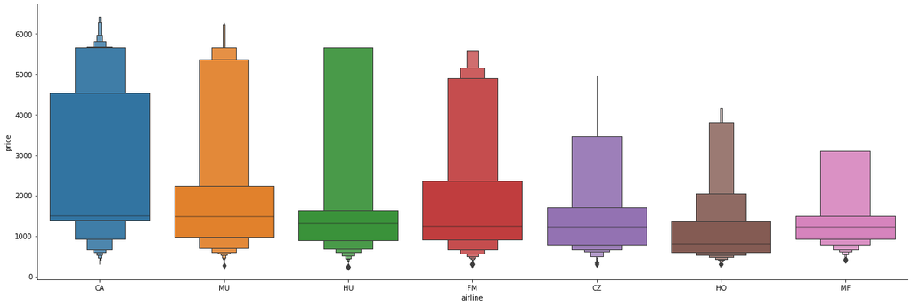

```python
sns.catplot(y = "price", x = "airline", data = dataset.sort_values("price", ascending = False), kind="boxen", height = 6, aspect = 3)
plt.show()
```

# Plot of Cabin Class

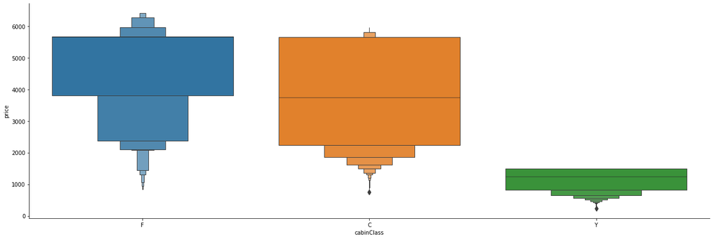

```python
sns.catplot(y = "price", x = "cabinClass", data = dataset.sort_values("price", ascending = False), kind="boxen", height = 6, aspect = 3)
plt.show()
```

# Creating priceCategory in place of priceClass attribute

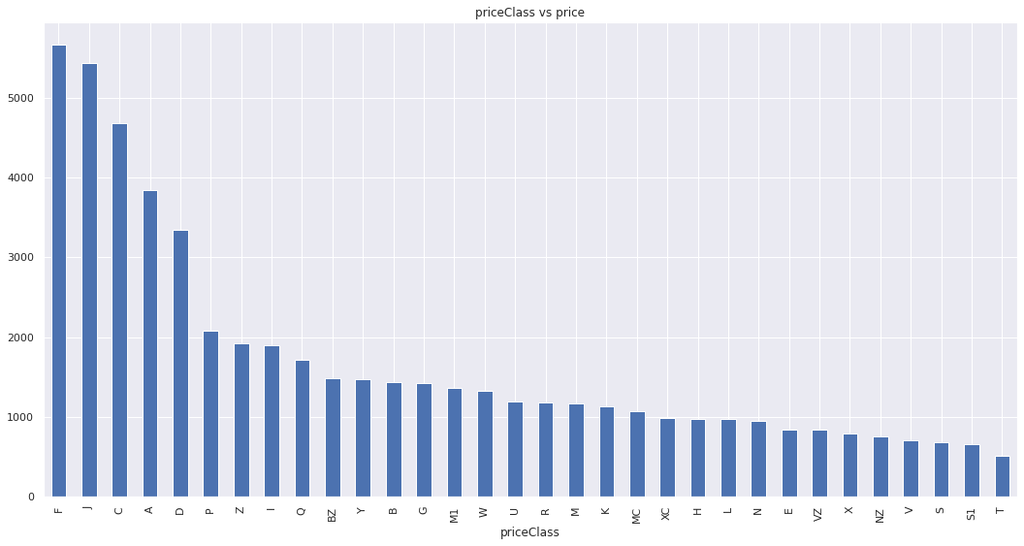

```python
data = dataset.copy()
fig= plt.figure(figsize=(18,9))
sns.set()
data.groupby('priceClass')['price'].mean().sort_values(ascending = False).plot.bar()
plt.title('priceClass vs price')
plt.show()
```

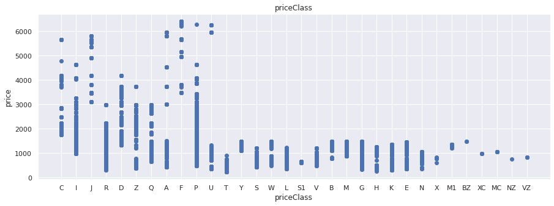

```python
fig= plt.figure(figsize=(15,5))
data=dataset.copy()
plt.scatter(data['priceClass'],data['price'])
plt.xlabel('priceClass')
plt.ylabel('price')
plt.title('priceClass')
plt.show()
```

```python
dataset["priceClass"].value_counts()
```

```
Y     68127
J     58181
B     54632
W     36892
R     33361
F     33175
V     25728
I     25241
Q     24992
P     22496
K     20780
N     18789
S     17197
C     16355
A     16141
L     15098
G     14379
Z     14279
T     11177
D     10617
U      7587
M      6423
S1     5427
H      4865
E      3254
X      1886
M1     1650
MC        4
VZ        3
XC        3
BZ        2
NZ        1
Name: priceClass, dtype: int64
```

A new attrbute priceCategory is created by grouping the values of priceClass. This is done by visualising the abovementioned plots intuitively.

```python
dataset['priceCategory']= dataset['priceClass']
```

```python
dataset["priceCategory"].replace({"Y": "cat1","B": "cat1","W": "cat1","V": "cat1","K": "cat1","N": "cat1","S": "cat1","L": "cat1","G": "cat1","T": "cat1","U": "cat1","M": "cat1","H": "cat1","E": "cat1","I": "cat2","Q": "cat2","P": "cat2","Z": "cat2","A": "cat2","R": "cat3","D": "cat3","C": "cat3","J": "cat4","F": "cat4","S1": "cat5","X": "cat5","M1": "cat5","MC": "cat5","XC": "cat5","BZ": "cat5","NZ": "cat5","VZ": "cat5"}, inplace=True)
```

```python
dataset.head()
```

|  | flightNumber | craftTypeCode | cabinClass | priceClass | price | rate | dateDifference | journey | indirectFlight | depMonth | depDate | depDay | depHour | creMonth | creDate | creDay | creHour | flightDuration | airline | priceCategory |
| --- | --- | --- | --- | --- | --- | --- | --- | --- | --- | --- | --- | --- | --- | --- | --- | --- | --- | --- | --- | --- |
| 0 | HO1252 | 320 | C | C | 1860 | 1.00 | 1 | 0 | 0 | 1 | 4 | 4 | 6 | 1 | 3 | 3 | 14 | 140.0 | HO | cat3 |
| 1 | MU5138 | 33L | C | I | 1640 | 0.31 | 1 | 0 | 0 | 1 | 4 | 4 | 7 | 1 | 3 | 3 | 14 | 135.0 | MU | cat2 |
| 2 | MU5138 | 33L | C | J | 5360 | 1.00 | 1 | 0 | 0 | 1 | 4 | 4 | 7 | 1 | 3 | 3 | 14 | 135.0 | MU | cat4 |
| 3 | HU7605 | 350 | C | I | 1635 | 0.29 | 1 | 0 | 0 | 1 | 4 | 4 | 7 | 1 | 3 | 3 | 14 | 135.0 | HU | cat2 |
| 4 | HU7605 | 350 | C | I | 1640 | 0.29 | 1 | 0 | 0 | 1 | 4 | 4 | 7 | 1 | 3 | 3 | 14 | 135.0 | HU | cat2 |

# Plotting priceCategory

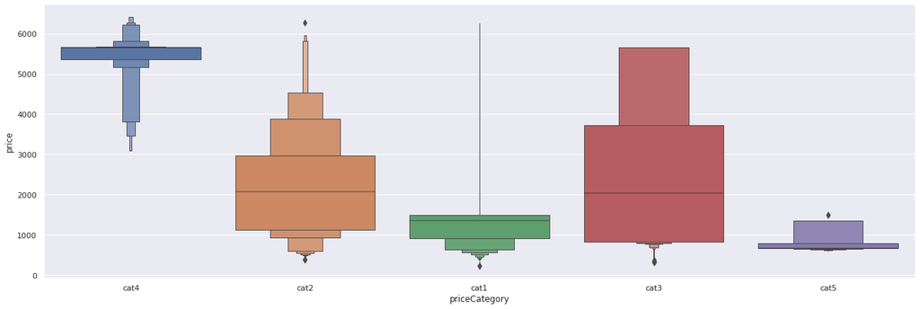

```python
sns.catplot(y = "price", x = "priceCategory", data = dataset.sort_values("price", ascending = False), kind="boxen", height = 6, aspect = 3)
plt.show()
```

```python
dataset["priceCategory"].value_counts()
```

```
cat1    304928
cat2    103149
cat4     91356
cat3     60333
cat5      8976
Name: priceCategory, dtype: int64
```

# Plotting carftTypeCode vs price

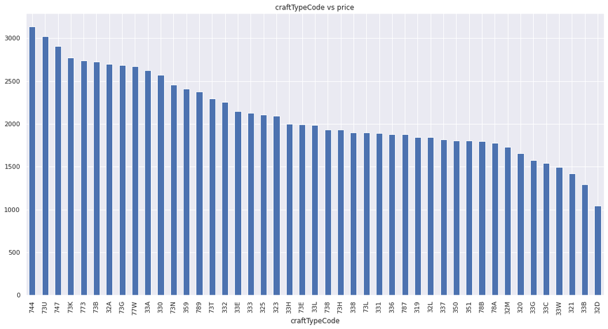

```python
data = dataset.copy()
fig= plt.figure(figsize=(18,9))
sns.set()
data.groupby('craftTypeCode')['price'].mean().sort_values(ascending = False).plot.bar()
plt.title('craftTypeCode vs price')
plt.show()
```

```python
dataset["craftTypeCode"].value_counts()
```

```
33L    111631
359     70634
333     58714
773     52681
325     31453
738     25871
321     22104
33A     17706
789     15299
73E     14815
73L     14487
32L     14182
747     14156
73K     11470
32A     10288
77W      9710
330      7498
350      7220
323      6295
338      5525
78A      5409
331      5400
33E      4980
744      4474
33G      3780
337      3126
33H      3026
320      2360
787      2212
78B      1893
332      1762
351      1611
73N      1530
33W      1091
336       920
319       695
73T       620
32M       582
73B       577
33C       469
73H       368
33B        92
73U        15
73G         7
32D         4
Name: craftTypeCode, dtype: int64
```

Here We have tried to group craftType code by visualization but failed so removing it assuming it is not important.

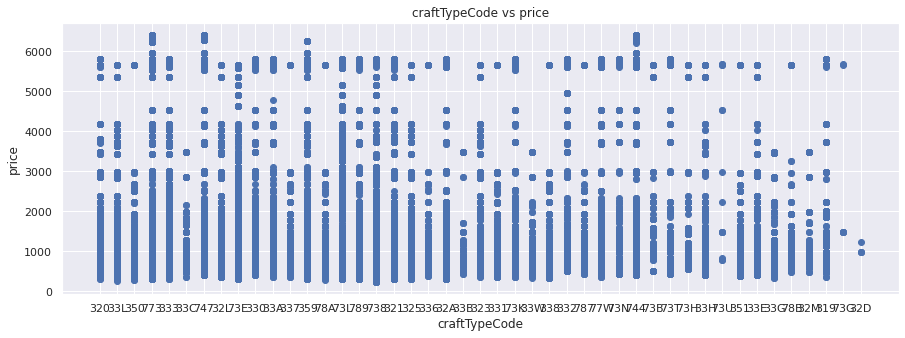

```python
fig= plt.figure(figsize=(15,5))
data=dataset.copy()
plt.scatter(data['craftTypeCode'],data['price'])
plt.xlabel('craftTypeCode')
plt.ylabel('price')
plt.title('craftTypeCode vs price')
plt.show()
```

# Dropping some more attributes

```python
dataset= dataset.drop(['flightNumber', 'craftTypeCode', 'priceClass'],axis = 1)
```

```python
dataset.head()
```

|  | cabinClass | price | rate | dateDifference | journey | indirectFlight | depMonth | depDate | depDay | depHour | creMonth | creDate | creDay | creHour | flightDuration | airline | priceCategory |
| --- | --- | --- | --- | --- | --- | --- | --- | --- | --- | --- | --- | --- | --- | --- | --- | --- | --- |
| 0 | C | 1860 | 1.00 | 1 | 0 | 0 | 1 | 4 | 4 | 6 | 1 | 3 | 3 | 14 | 140.0 | HO | cat3 |
| 1 | C | 1640 | 0.31 | 1 | 0 | 0 | 1 | 4 | 4 | 7 | 1 | 3 | 3 | 14 | 135.0 | MU | cat2 |
| 2 | C | 5360 | 1.00 | 1 | 0 | 0 | 1 | 4 | 4 | 7 | 1 | 3 | 3 | 14 | 135.0 | MU | cat4 |
| 3 | C | 1635 | 0.29 | 1 | 0 | 0 | 1 | 4 | 4 | 7 | 1 | 3 | 3 | 14 | 135.0 | HU | cat2 |
| 4 | C | 1640 | 0.29 | 1 | 0 | 0 | 1 | 4 | 4 | 7 | 1 | 3 | 3 | 14 | 135.0 | HU | cat2 |

# Plotting continuous_features

```python
continuous_features = ['rate', 'flightDuration', 'price']
```

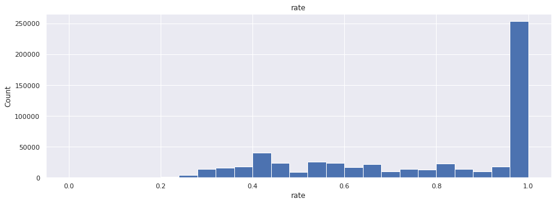

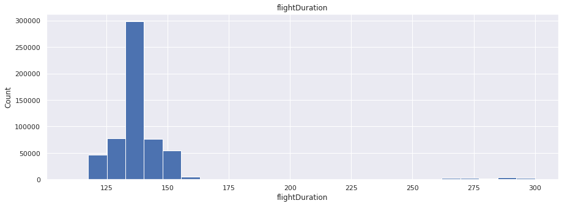

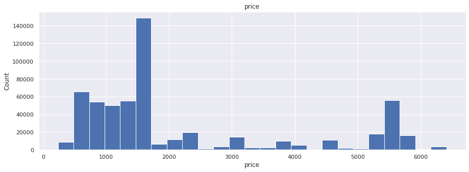

```python
for feature in continuous_features:
    fig= plt.figure(figsize=(15,5))
    data=dataset.copy()
    data[feature].hist(bins=25)
    plt.xlabel(feature)
    plt.ylabel("Count")
    plt.title(feature)
    plt.show()
```

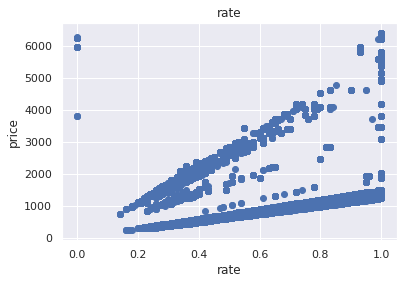

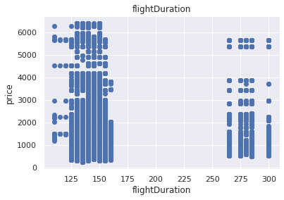

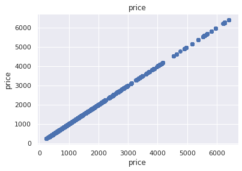

```python
for feature in continuous_features:
    data=dataset.copy()
    plt.scatter(data[feature],data['price'])
    plt.xlabel(feature)
    plt.ylabel('price')
    plt.title(feature)
    plt.show()
```

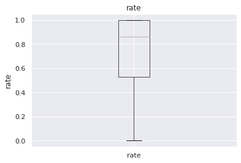

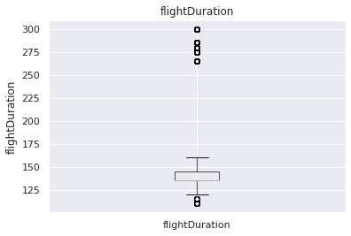

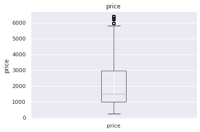

```python
for feature in continuous_features:
    data=dataset.copy()
    data.boxplot(column=feature)
    plt.ylabel(feature)
    plt.title(feature)
    plt.show()
```

# Removing Outliers

```python
dataset.describe()
```

|  | price | rate | dateDifference | journey | indirectFlight | depMonth | depDate | depDay | depHour | creMonth | creDate | creDay | creHour | flightDuration |
| --- | --- | --- | --- | --- | --- | --- | --- | --- | --- | --- | --- | --- | --- | --- |
| count | 568742.000000 | 568742.000000 | 568742.000000 | 568742.000000 | 568742.000000 | 568742.000000 | 568742.000000 | 568742.000000 | 568742.000000 | 568742.000000 | 568742.000000 | 568742.000000 | 568742.000000 | 568742.000000 |
| mean | 2203.121143 | 0.768126 | 6.588942 | 0.471929 | 0.019097 | 3.448801 | 15.631154 | 3.016809 | 13.973818 | 3.260563 | 14.716903 | 3.036612 | 11.653864 | 140.855010 |
| std | 1747.306158 | 0.250099 | 7.407269 | 0.499212 | 0.136864 | 2.094899 | 8.240068 | 2.005487 | 4.627445 | 1.995600 | 8.117110 | 1.921924 | 4.918747 | 21.996365 |
| min | 235.000000 | 0.000000 | 0.000000 | 0.000000 | 0.000000 | 1.000000 | 1.000000 | 0.000000 | 6.000000 | 1.000000 | 1.000000 | 0.000000 | 0.000000 | 110.000000 |
| 25% | 1010.000000 | 0.530000 | 2.000000 | 0.000000 | 0.000000 | 2.000000 | 9.000000 | 1.000000 | 10.000000 | 2.000000 | 8.000000 | 1.000000 | 11.000000 | 135.000000 |
| 50% | 1490.000000 | 0.860000 | 5.000000 | 0.000000 | 0.000000 | 3.000000 | 16.000000 | 3.000000 | 14.000000 | 3.000000 | 14.000000 | 3.000000 | 12.000000 | 135.000000 |
| 75% | 2980.000000 | 1.000000 | 7.000000 | 1.000000 | 0.000000 | 5.000000 | 22.000000 | 5.000000 | 18.000000 | 5.000000 | 21.000000 | 5.000000 | 13.000000 | 145.000000 |
| max | 6410.000000 | 1.000000 | 30.000000 | 1.000000 | 1.000000 | 8.000000 | 31.000000 | 6.000000 | 22.000000 | 7.000000 | 31.000000 | 6.000000 | 23.000000 | 300.000000 |

```python
out_features = ['flightDuration']
```

```python
Q1 = dataset[out_features].quantile(0.25)
Q3 = dataset[out_features].quantile(0.75)
IQR = Q3 - Q1
print(IQR)
```

```
flightDuration    10.0
dtype: float64
```

```python
datasetOutf = dataset[((dataset[out_features] < (Q1 - 1.5 * IQR)) |(dataset[out_features] > (Q3 + 1.5 * IQR))).any(axis=1)]
```

```python
datasetOutf.shape
```

```
(12097, 17)
```

```python
datasetOutf.describe()
```

|  | price | rate | dateDifference | journey | indirectFlight | depMonth | depDate | depDay | depHour | creMonth | creDate | creDay | creHour | flightDuration |
| --- | --- | --- | --- | --- | --- | --- | --- | --- | --- | --- | --- | --- | --- | --- |
| count | 12097.000000 | 12097.000000 | 12097.000000 | 12097.000000 | 12097.000000 | 12097.000000 | 12097.000000 | 12097.000000 | 12097.000000 | 12097.000000 | 12097.000000 | 12097.000000 | 12097.000000 | 12097.000000 |
| mean | 2024.967347 | 0.687903 | 5.924775 | 0.472845 | 0.897826 | 3.200215 | 15.934943 | 2.993469 | 10.323799 | 3.048194 | 14.527899 | 3.024221 | 11.892287 | 280.874184 |
| std | 1762.342703 | 0.248868 | 6.427786 | 0.499283 | 0.302890 | 2.027406 | 7.695392 | 1.972079 | 2.807196 | 1.920478 | 7.621290 | 1.918432 | 4.613041 | 14.220778 |
| min | 500.000000 | 0.180000 | 0.000000 | 0.000000 | 0.000000 | 1.000000 | 1.000000 | 0.000000 | 7.000000 | 1.000000 | 1.000000 | 0.000000 | 0.000000 | 110.000000 |
| 25% | 830.000000 | 0.450000 | 2.000000 | 0.000000 | 1.000000 | 2.000000 | 10.000000 | 1.000000 | 7.000000 | 2.000000 | 9.000000 | 1.000000 | 11.000000 | 275.000000 |
| 50% | 1390.000000 | 0.620000 | 4.000000 | 0.000000 | 1.000000 | 3.000000 | 17.000000 | 3.000000 | 13.000000 | 2.000000 | 14.000000 | 3.000000 | 12.000000 | 285.000000 |
| 75% | 2240.000000 | 1.000000 | 7.000000 | 1.000000 | 1.000000 | 4.000000 | 22.000000 | 5.000000 | 13.000000 | 4.000000 | 20.000000 | 5.000000 | 13.000000 | 285.000000 |
| max | 6270.000000 | 1.000000 | 30.000000 | 1.000000 | 1.000000 | 8.000000 | 31.000000 | 6.000000 | 13.000000 | 7.000000 | 31.000000 | 6.000000 | 23.000000 | 300.000000 |

```python
dataset = dataset[~((dataset[out_features] < (Q1 - 1.5 * IQR)) |(dataset[out_features] > (Q3 + 1.5 * IQR))).any(axis=1)]
```

We have removed the outliers of flightDuration only. It's being noticed that while removing flightDuration, transitAirport rather one variale of indirectFlight got is also got removed

# Plotting barplot for mean of price grouped by discrete_features

```python
discrete_features = ['journey','cabinClass','dateDifference','indirectFlight','depMonth','depDate', 'depDay', 'depHour','creMonth','creDate', 'creDay', 'creHour','airline','priceCategory']
```

```python
discrete_features
```

```
['journey',
 'cabinClass',
 'dateDifference',
 'indirectFlight',
 'depMonth',
 'depDate',
 'depDay',
 'depHour',
 'creMonth',
 'creDate',
 'creDay',
 'creHour',
 'airline',
 'priceCategory']
```

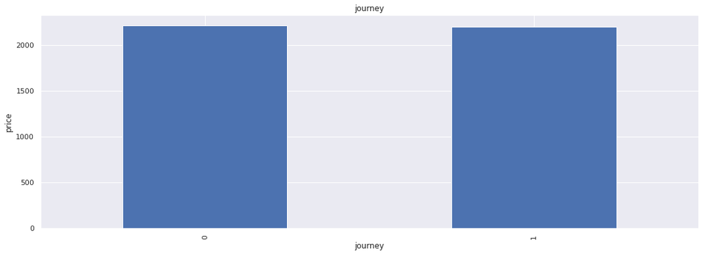

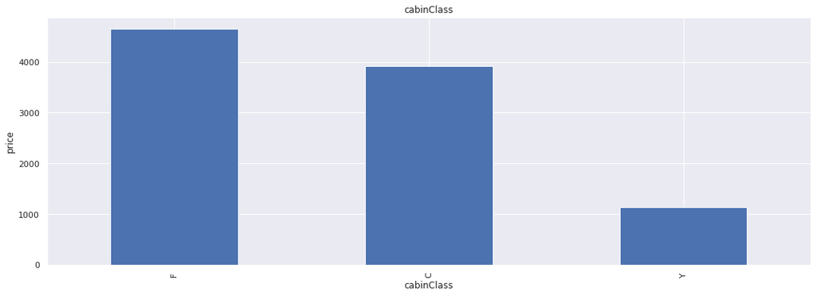

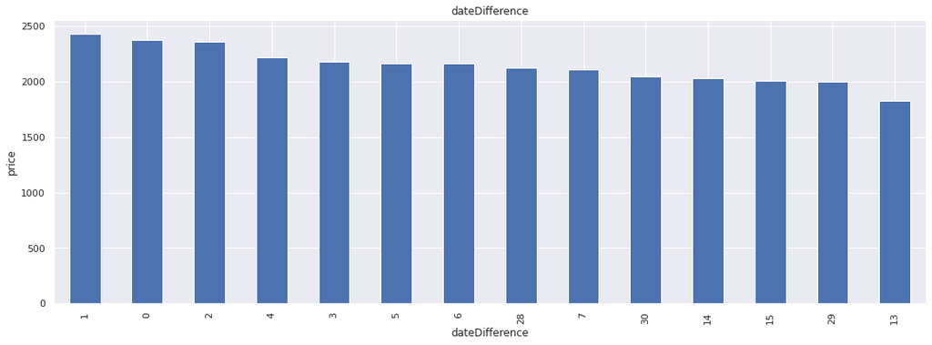

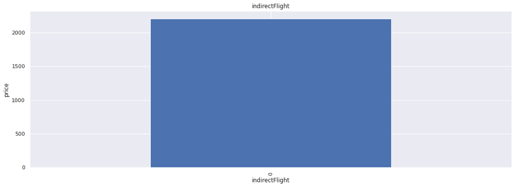

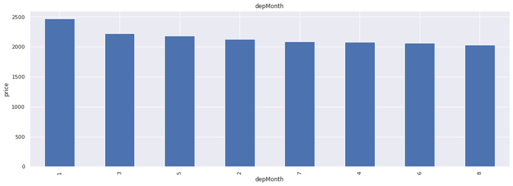

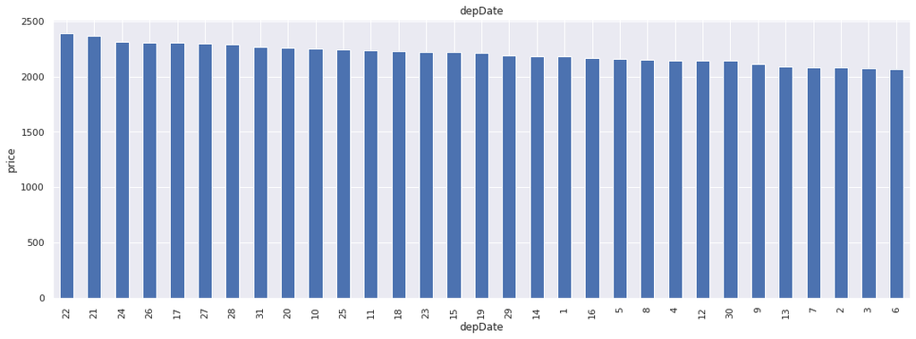

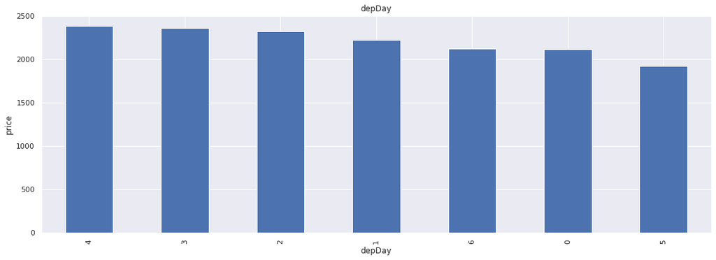

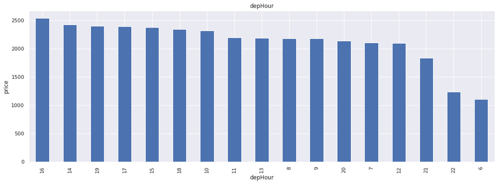

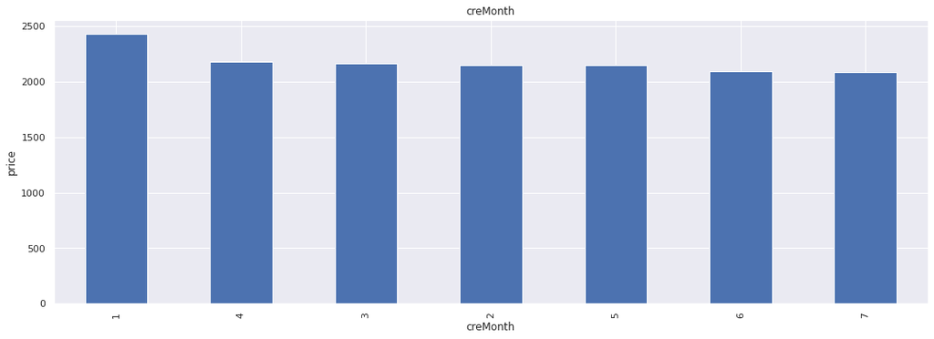

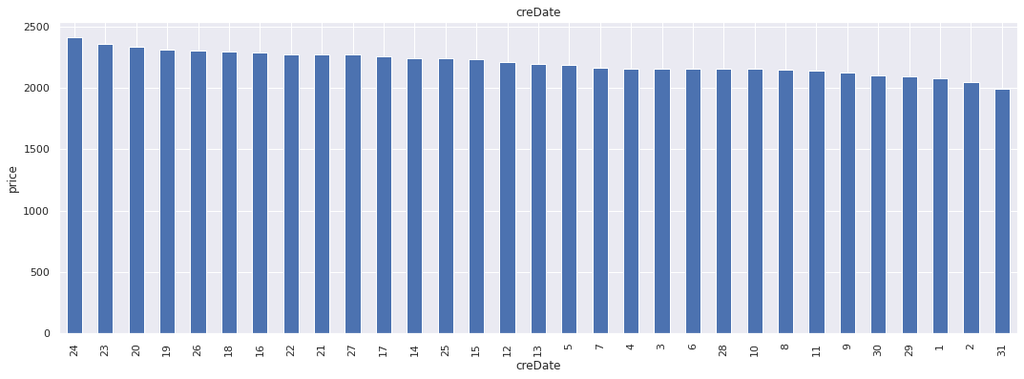

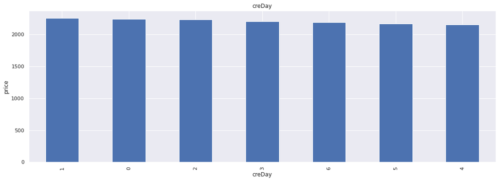

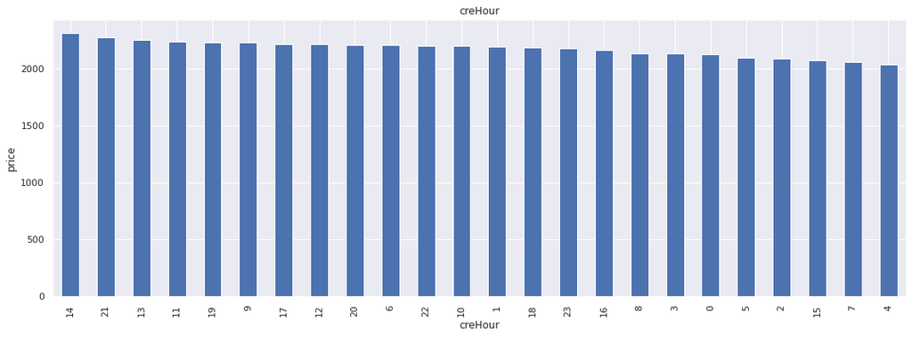

[2 more figures not shown]

```python
for feature in discrete_features:
    fig= plt.figure(figsize=(18,6))
    sns.set()
    data = dataset.copy()
    data.groupby(feature)['price'].mean().sort_values(ascending = False).plot.bar()
    plt.xlabel(feature)
    plt.ylabel('price')
    plt.title(feature)
    plt.show()
```

# Dropping more attributes

```python
dataset = dataset.drop(['indirectFlight'],axis = 1)
```

```python
dataset.shape
```

```
(556645, 16)
```

```python
dataset.head()
```

|  | cabinClass | price | rate | dateDifference | journey | depMonth | depDate | depDay | depHour | creMonth | creDate | creDay | creHour | flightDuration | airline | priceCategory |
| --- | --- | --- | --- | --- | --- | --- | --- | --- | --- | --- | --- | --- | --- | --- | --- | --- |
| 0 | C | 1860 | 1.00 | 1 | 0 | 1 | 4 | 4 | 6 | 1 | 3 | 3 | 14 | 140.0 | HO | cat3 |
| 1 | C | 1640 | 0.31 | 1 | 0 | 1 | 4 | 4 | 7 | 1 | 3 | 3 | 14 | 135.0 | MU | cat2 |
| 2 | C | 5360 | 1.00 | 1 | 0 | 1 | 4 | 4 | 7 | 1 | 3 | 3 | 14 | 135.0 | MU | cat4 |
| 3 | C | 1635 | 0.29 | 1 | 0 | 1 | 4 | 4 | 7 | 1 | 3 | 3 | 14 | 135.0 | HU | cat2 |
| 4 | C | 1640 | 0.29 | 1 | 0 | 1 | 4 | 4 | 7 | 1 | 3 | 3 | 14 | 135.0 | HU | cat2 |

# Correlation Heatmap

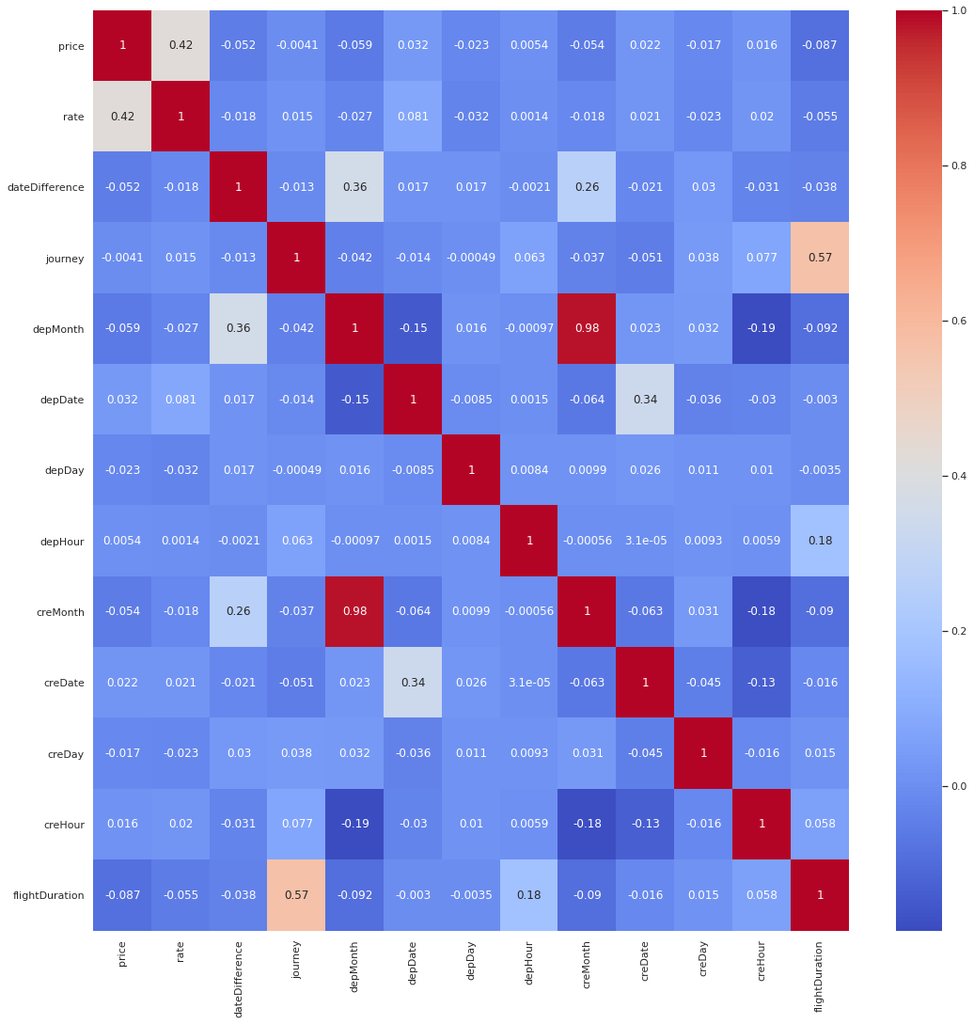

```python
# Finds correlation between Independent and dependent attributes
plt.figure(figsize = (18,18))
sns.heatmap(dataset.corr(), annot = True, cmap = "coolwarm")
plt.show()
```

```python
dataset.shape
```

```
(556645, 16)
```

```python
dataset.head()
```

|  | cabinClass | price | rate | dateDifference | journey | depMonth | depDate | depDay | depHour | creMonth | creDate | creDay | creHour | flightDuration | airline | priceCategory |
| --- | --- | --- | --- | --- | --- | --- | --- | --- | --- | --- | --- | --- | --- | --- | --- | --- |
| 0 | C | 1860 | 1.00 | 1 | 0 | 1 | 4 | 4 | 6 | 1 | 3 | 3 | 14 | 140.0 | HO | cat3 |
| 1 | C | 1640 | 0.31 | 1 | 0 | 1 | 4 | 4 | 7 | 1 | 3 | 3 | 14 | 135.0 | MU | cat2 |
| 2 | C | 5360 | 1.00 | 1 | 0 | 1 | 4 | 4 | 7 | 1 | 3 | 3 | 14 | 135.0 | MU | cat4 |
| 3 | C | 1635 | 0.29 | 1 | 0 | 1 | 4 | 4 | 7 | 1 | 3 | 3 | 14 | 135.0 | HU | cat2 |
| 4 | C | 1640 | 0.29 | 1 | 0 | 1 | 4 | 4 | 7 | 1 | 3 | 3 | 14 | 135.0 | HU | cat2 |

```python
duplicate = dataset[dataset.duplicated(keep = False)]
duplicate
```

|  | cabinClass | price | rate | dateDifference | journey | depMonth | depDate | depDay | depHour | creMonth | creDate | creDay | creHour | flightDuration | airline | priceCategory |
| --- | --- | --- | --- | --- | --- | --- | --- | --- | --- | --- | --- | --- | --- | --- | --- | --- |
| 24 | C | 2240 | 0.42 | 1 | 0 | 1 | 4 | 4 | 11 | 1 | 3 | 3 | 14 | 135.0 | MU | cat2 |
| 25 | C | 5360 | 1.00 | 1 | 0 | 1 | 4 | 4 | 11 | 1 | 3 | 3 | 14 | 135.0 | MU | cat4 |
| 29 | C | 2240 | 0.42 | 1 | 0 | 1 | 4 | 4 | 11 | 1 | 3 | 3 | 14 | 135.0 | MU | cat2 |
| 30 | C | 5360 | 1.00 | 1 | 0 | 1 | 4 | 4 | 11 | 1 | 3 | 3 | 14 | 135.0 | MU | cat4 |
| 40 | C | 4170 | 0.78 | 1 | 0 | 1 | 4 | 4 | 15 | 1 | 3 | 3 | 14 | 130.0 | MU | cat3 |
| ... | ... | ... | ... | ... | ... | ... | ... | ... | ... | ... | ... | ... | ... | ... | ... | ... |
| 568894 | Y | 830 | 0.56 | 7 | 1 | 7 | 21 | 6 | 21 | 7 | 14 | 6 | 23 | 140.0 | CA | cat1 |
| 568895 | Y | 810 | 0.55 | 7 | 1 | 7 | 21 | 6 | 21 | 7 | 14 | 6 | 23 | 140.0 | CA | cat1 |
| 568896 | Y | 830 | 0.56 | 7 | 1 | 7 | 21 | 6 | 21 | 7 | 14 | 6 | 23 | 140.0 | CA | cat1 |
| 568902 | Y | 1070 | 0.72 | 7 | 1 | 7 | 21 | 6 | 21 | 7 | 14 | 6 | 23 | 155.0 | HO | cat2 |
| 568904 | Y | 1070 | 0.72 | 7 | 1 | 7 | 21 | 6 | 21 | 7 | 14 | 6 | 23 | 155.0 | HO | cat2 |

242748 rows × 16 columns

```python
dataset = dataset.drop_duplicates(keep = 'first')
```

```python
#This will check the missing values percentage in columns
features_with_na=[features for features in dataset.columns if dataset[features].isnull().sum()>1]
for feature in features_with_na:
    print(feature, np.round(dataset[feature].isnull().mean()*100, 4),  ' % missing values')
```

```python
dataset.shape
```

```
(407506, 16)
```

```python
dataset.head()
```

|  | cabinClass | price | rate | dateDifference | journey | depMonth | depDate | depDay | depHour | creMonth | creDate | creDay | creHour | flightDuration | airline | priceCategory |
| --- | --- | --- | --- | --- | --- | --- | --- | --- | --- | --- | --- | --- | --- | --- | --- | --- |
| 0 | C | 1860 | 1.00 | 1 | 0 | 1 | 4 | 4 | 6 | 1 | 3 | 3 | 14 | 140.0 | HO | cat3 |
| 1 | C | 1640 | 0.31 | 1 | 0 | 1 | 4 | 4 | 7 | 1 | 3 | 3 | 14 | 135.0 | MU | cat2 |
| 2 | C | 5360 | 1.00 | 1 | 0 | 1 | 4 | 4 | 7 | 1 | 3 | 3 | 14 | 135.0 | MU | cat4 |
| 3 | C | 1635 | 0.29 | 1 | 0 | 1 | 4 | 4 | 7 | 1 | 3 | 3 | 14 | 135.0 | HU | cat2 |
| 4 | C | 1640 | 0.29 | 1 | 0 | 1 | 4 | 4 | 7 | 1 | 3 | 3 | 14 | 135.0 | HU | cat2 |

```python
dataEnco = dataset
```

# One Hot encoding for cabinClass, airline, priceCategory

```python
dataEnco.head()
```

|  | cabinClass | price | rate | dateDifference | journey | depMonth | depDate | depDay | depHour | creMonth | creDate | creDay | creHour | flightDuration | airline | priceCategory |
| --- | --- | --- | --- | --- | --- | --- | --- | --- | --- | --- | --- | --- | --- | --- | --- | --- |
| 0 | C | 1860 | 1.00 | 1 | 0 | 1 | 4 | 4 | 6 | 1 | 3 | 3 | 14 | 140.0 | HO | cat3 |
| 1 | C | 1640 | 0.31 | 1 | 0 | 1 | 4 | 4 | 7 | 1 | 3 | 3 | 14 | 135.0 | MU | cat2 |
| 2 | C | 5360 | 1.00 | 1 | 0 | 1 | 4 | 4 | 7 | 1 | 3 | 3 | 14 | 135.0 | MU | cat4 |
| 3 | C | 1635 | 0.29 | 1 | 0 | 1 | 4 | 4 | 7 | 1 | 3 | 3 | 14 | 135.0 | HU | cat2 |
| 4 | C | 1640 | 0.29 | 1 | 0 | 1 | 4 | 4 | 7 | 1 | 3 | 3 | 14 | 135.0 | HU | cat2 |

```python
dataEnco.shape
```

```
(407506, 16)
```

```python
# OneHotEncoding
categorical_cols = ['cabinClass', 'airline', 'priceCategory']
dataframe = pd.get_dummies(dataEnco, columns = categorical_cols, drop_first = True)
dataframe
```

|  | price | rate | dateDifference | journey | depMonth | depDate | depDay | depHour | creMonth | creDate | creDay | creHour | flightDuration | cabinClass_F | cabinClass_Y | airline_CZ | airline_FM | airline_HO | airline_HU | airline_MF | airline_MU | priceCategory_cat2 | priceCategory_cat3 | priceCategory_cat4 | priceCategory_cat5 |
| --- | --- | --- | --- | --- | --- | --- | --- | --- | --- | --- | --- | --- | --- | --- | --- | --- | --- | --- | --- | --- | --- | --- | --- | --- | --- |
| 0 | 1860 | 1.00 | 1 | 0 | 1 | 4 | 4 | 6 | 1 | 3 | 3 | 14 | 140.0 | 0 | 0 | 0 | 0 | 1 | 0 | 0 | 0 | 0 | 1 | 0 | 0 |
| 1 | 1640 | 0.31 | 1 | 0 | 1 | 4 | 4 | 7 | 1 | 3 | 3 | 14 | 135.0 | 0 | 0 | 0 | 0 | 0 | 0 | 0 | 1 | 1 | 0 | 0 | 0 |
| 2 | 5360 | 1.00 | 1 | 0 | 1 | 4 | 4 | 7 | 1 | 3 | 3 | 14 | 135.0 | 0 | 0 | 0 | 0 | 0 | 0 | 0 | 1 | 0 | 0 | 1 | 0 |
| 3 | 1635 | 0.29 | 1 | 0 | 1 | 4 | 4 | 7 | 1 | 3 | 3 | 14 | 135.0 | 0 | 0 | 0 | 0 | 0 | 1 | 0 | 0 | 1 | 0 | 0 | 0 |
| 4 | 1640 | 0.29 | 1 | 0 | 1 | 4 | 4 | 7 | 1 | 3 | 3 | 14 | 135.0 | 0 | 0 | 0 | 0 | 0 | 1 | 0 | 0 | 1 | 0 | 0 | 0 |
| ... | ... | ... | ... | ... | ... | ... | ... | ... | ... | ... | ... | ... | ... | ... | ... | ... | ... | ... | ... | ... | ... | ... | ... | ... | ... |
| 568905 | 1190 | 0.80 | 7 | 1 | 7 | 21 | 6 | 21 | 7 | 14 | 6 | 23 | 155.0 | 0 | 1 | 0 | 0 | 1 | 0 | 0 | 0 | 1 | 0 | 0 | 0 |
| 568906 | 1042 | 0.70 | 7 | 1 | 7 | 21 | 6 | 21 | 7 | 14 | 6 | 23 | 155.0 | 0 | 1 | 0 | 0 | 1 | 0 | 0 | 0 | 1 | 0 | 0 | 0 |
| 568907 | 1050 | 0.71 | 7 | 1 | 7 | 21 | 6 | 21 | 7 | 14 | 6 | 23 | 155.0 | 0 | 1 | 0 | 0 | 1 | 0 | 0 | 0 | 1 | 0 | 0 | 0 |
| 568908 | 1090 | 0.74 | 7 | 1 | 7 | 21 | 6 | 21 | 7 | 14 | 6 | 23 | 155.0 | 0 | 1 | 0 | 0 | 1 | 0 | 0 | 0 | 1 | 0 | 0 | 0 |
| 568909 | 1490 | 1.00 | 7 | 1 | 7 | 21 | 6 | 21 | 7 | 14 | 6 | 23 | 155.0 | 0 | 1 | 0 | 0 | 1 | 0 | 0 | 0 | 0 | 0 | 0 | 0 |

407506 rows × 25 columns

```python
#This will check the missing values percentage in columns
features_with_na=[features for features in dataframe.columns if dataframe[features].isnull().sum()>1]
for feature in features_with_na:
    print(feature, np.round(dataframe[feature].isnull().mean()*100, 4),  ' % missing values')
```

```python
dataframe.shape
```

```
(407506, 25)
```

```python
dataframe.head()
```

|  | price | rate | dateDifference | journey | depMonth | depDate | depDay | depHour | creMonth | creDate | creDay | creHour | flightDuration | cabinClass_F | cabinClass_Y | airline_CZ | airline_FM | airline_HO | airline_HU | airline_MF | airline_MU | priceCategory_cat2 | priceCategory_cat3 | priceCategory_cat4 | priceCategory_cat5 |
| --- | --- | --- | --- | --- | --- | --- | --- | --- | --- | --- | --- | --- | --- | --- | --- | --- | --- | --- | --- | --- | --- | --- | --- | --- | --- |
| 0 | 1860 | 1.00 | 1 | 0 | 1 | 4 | 4 | 6 | 1 | 3 | 3 | 14 | 140.0 | 0 | 0 | 0 | 0 | 1 | 0 | 0 | 0 | 0 | 1 | 0 | 0 |
| 1 | 1640 | 0.31 | 1 | 0 | 1 | 4 | 4 | 7 | 1 | 3 | 3 | 14 | 135.0 | 0 | 0 | 0 | 0 | 0 | 0 | 0 | 1 | 1 | 0 | 0 | 0 |
| 2 | 5360 | 1.00 | 1 | 0 | 1 | 4 | 4 | 7 | 1 | 3 | 3 | 14 | 135.0 | 0 | 0 | 0 | 0 | 0 | 0 | 0 | 1 | 0 | 0 | 1 | 0 |
| 3 | 1635 | 0.29 | 1 | 0 | 1 | 4 | 4 | 7 | 1 | 3 | 3 | 14 | 135.0 | 0 | 0 | 0 | 0 | 0 | 1 | 0 | 0 | 1 | 0 | 0 | 0 |
| 4 | 1640 | 0.29 | 1 | 0 | 1 | 4 | 4 | 7 | 1 | 3 | 3 | 14 | 135.0 | 0 | 0 | 0 | 0 | 0 | 1 | 0 | 0 | 1 | 0 | 0 | 0 |

```python
dataframe.tail()
```

|  | price | rate | dateDifference | journey | depMonth | depDate | depDay | depHour | creMonth | creDate | creDay | creHour | flightDuration | cabinClass_F | cabinClass_Y | airline_CZ | airline_FM | airline_HO | airline_HU | airline_MF | airline_MU | priceCategory_cat2 | priceCategory_cat3 | priceCategory_cat4 | priceCategory_cat5 |
| --- | --- | --- | --- | --- | --- | --- | --- | --- | --- | --- | --- | --- | --- | --- | --- | --- | --- | --- | --- | --- | --- | --- | --- | --- | --- |
| 568905 | 1190 | 0.80 | 7 | 1 | 7 | 21 | 6 | 21 | 7 | 14 | 6 | 23 | 155.0 | 0 | 1 | 0 | 0 | 1 | 0 | 0 | 0 | 1 | 0 | 0 | 0 |
| 568906 | 1042 | 0.70 | 7 | 1 | 7 | 21 | 6 | 21 | 7 | 14 | 6 | 23 | 155.0 | 0 | 1 | 0 | 0 | 1 | 0 | 0 | 0 | 1 | 0 | 0 | 0 |
| 568907 | 1050 | 0.71 | 7 | 1 | 7 | 21 | 6 | 21 | 7 | 14 | 6 | 23 | 155.0 | 0 | 1 | 0 | 0 | 1 | 0 | 0 | 0 | 1 | 0 | 0 | 0 |
| 568908 | 1090 | 0.74 | 7 | 1 | 7 | 21 | 6 | 21 | 7 | 14 | 6 | 23 | 155.0 | 0 | 1 | 0 | 0 | 1 | 0 | 0 | 0 | 1 | 0 | 0 | 0 |
| 568909 | 1490 | 1.00 | 7 | 1 | 7 | 21 | 6 | 21 | 7 | 14 | 6 | 23 | 155.0 | 0 | 1 | 0 | 0 | 1 | 0 | 0 | 0 | 0 | 0 | 0 | 0 |

```python
duplicate = dataframe[dataset.duplicated(keep = False)]
duplicate
```

|  | price | rate | dateDifference | journey | depMonth | depDate | depDay | depHour | creMonth | creDate | creDay | creHour | flightDuration | cabinClass_F | cabinClass_Y | airline_CZ | airline_FM | airline_HO | airline_HU | airline_MF | airline_MU | priceCategory_cat2 | priceCategory_cat3 | priceCategory_cat4 | priceCategory_cat5 |
| --- | --- | --- | --- | --- | --- | --- | --- | --- | --- | --- | --- | --- | --- | --- | --- | --- | --- | --- | --- | --- | --- | --- | --- | --- | --- |

```python
df = dataframe
```

# Preparation for Modeling

Dataframe is splitted into two part training & test. The Test data generated here will be used at the end

```python
# Splitting data into train and test data
df_train = df.sample(frac=0.80, random_state=99)
df_test = df.loc[~df.index.isin(df_train.index), :]
```

```python
print("The size of training input is", df_train.shape)
print(50 *'-')
print("The size of testing input is", df_test.shape)
```

```
The size of training input is (326005, 25)
--------------------------------------------------
The size of testing input is (81501, 25)
```

y and X are assigned

```python
y = df_train['price']
X = df_train.drop('price', axis = 1)
```

Again we are splitting the training data into training and test data

```python
# Splitting data into train and test data
X_train, X_test, y_train, y_test = train_test_split(X, y, test_size = 0.2)
```

```python
print("The size of training input is", X_train.shape)
print("The size of training output is", y_train.shape)
print(50 *'-')
print("The size of testing input is", X_test.shape)
print("The size of testing output is", y_test.shape)
```

```
The size of training input is (260804, 24)
The size of training output is (260804,)
--------------------------------------------------
The size of testing input is (65201, 24)
The size of testing output is (65201,)
```